# Math 253 Assignment 1

Jingjing Yang

Sept. 15, 2015

*Source file*

# Exercise 1 in ISL Section 2.4

## (a) Large n, small p

When n is extremely large, and p is small, a flexible method performs better because having lots of data gives more basis for detail in fhat.

## (b) Large p, small n

When p is large, and n is small, an inflexible method performs better because having a small number of observations can easily lead to overfitting.

## (c) Relationship highly non-linear

When the relationship between the predictors and response is highly non-linear, a flexible method performs better because it can better capture the non-linearity of the relationship.

## (d) Variance extremely high

When the variance of the error terms is extremely high, an inflexible method performs better because a flexible model fits too much of the noise (variance) in the problem.

# Exercise 3 in ISL Section 2.4

## (b) Explain the shapes

Typical (squared) bias slopes downward because by definition, the less flexible the bigger bias is. Variance slopes upward because more flexible models generates more variance. Training error slopes down because as flexibility increases, the model gets better in picking up the patterns in the training data. Test error first slopes down and then slopes up again because as flexibility exceeds certain point, the model becomes overfitted, which increases the test MSE. Bayes (irreducible) error is a horizontal line because it’s determined by the unmeasured variables and unmeasurable variation in the data sets.

# Exercise 6 in ISL Section 2.4

## Differences between parametric and non-parametric approaches

Parametric methods first make an assumption about the functional form, or shape of f. It simplies the problem by reducing the problem of estimating f down to one of estimating a set of paramters. The disadvantage of a parametric method is that the method we choose will usually not match the true unknown form of f. Non-parametric methods do not make explicit assumptions about the functional form of f, so they have the potential to accurately fit a wider range of possible shapes for f. But the downside is that they require a very large number of observations to obstain an accurate estimate for f.

# Exercise 8 in ISL Section 2.4

## (a) Read the data

```r
# download.file("http://www-bcf.usc.edu/~gareth/ISL/College.csv", destfile = "College.csv")
college_file_name <- "/Users/JingjingYang/Dropbox/fall 2015/253 statistical computing/assignment/assignment1/College.csv"
college <- read.csv(college_file_name, header = T, na.strings = "?")
```

## (b) Rownames

```r
rownames(college) = college[,1]
college = college[,-1]
```

## (c)

### i. Summary

```r
summary(college)
```

```
##  Private        Apps           Accept          Enroll       Top10perc
##  No :212   Min.   :   81   Min.   :   72   Min.   :  35   Min.   : 1.00
##  Yes:565   1st Qu.:  776   1st Qu.:  604   1st Qu.: 242   1st Qu.:15.00
##            Median : 1558   Median : 1110   Median : 434   Median :23.00
##            Mean   : 3002   Mean   : 2019   Mean   : 780   Mean   :27.56
##            3rd Qu.: 3624   3rd Qu.: 2424   3rd Qu.: 902   3rd Qu.:35.00
##            Max.   :48094   Max.   :26330   Max.   :6392   Max.   :96.00
##    Top25perc      F.Undergrad     P.Undergrad         Outstate
##  Min.   :  9.0   Min.   :  139   Min.   :    1.0   Min.   : 2340
##  1st Qu.: 41.0   1st Qu.:  992   1st Qu.:   95.0   1st Qu.: 7320
##  Median : 54.0   Median : 1707   Median :  353.0   Median : 9990
##  Mean   : 55.8   Mean   : 3700   Mean   :  855.3   Mean   :10441
##  3rd Qu.: 69.0   3rd Qu.: 4005   3rd Qu.:  967.0   3rd Qu.:12925
##  Max.   :100.0   Max.   :31643   Max.   :21836.0   Max.   :21700
##    Room.Board       Books           Personal         PhD
##  Min.   :1780   Min.   :  96.0   Min.   : 250   Min.   :  8.00
##  1st Qu.:3597   1st Qu.: 470.0   1st Qu.: 850   1st Qu.: 62.00
##  Median :4200   Median : 500.0   Median :1200   Median : 75.00
##  Mean   :4358   Mean   : 549.4   Mean   :1341   Mean   : 72.66
##  3rd Qu.:5050   3rd Qu.: 600.0   3rd Qu.:1700   3rd Qu.: 85.00
##  Max.   :8124   Max.   :2340.0   Max.   :6800   Max.   :103.00
##     Terminal       S.F.Ratio      perc.alumni        Expend
##  Min.   : 24.0   Min.   : 2.50   Min.   : 0.00   Min.   : 3186
##  1st Qu.: 71.0   1st Qu.:11.50   1st Qu.:13.00   1st Qu.: 6751
##  Median : 82.0   Median :13.60   Median :21.00   Median : 8377
##  Mean   : 79.7   Mean   :14.09   Mean   :22.74   Mean   : 9660
##  3rd Qu.: 92.0   3rd Qu.:16.50   3rd Qu.:31.00   3rd Qu.:10830
##  Max.   :100.0   Max.   :39.80   Max.   :64.00   Max.   :56233
##    Grad.Rate
##  Min.   : 10.00
##  1st Qu.: 53.00
##  Median : 65.00
##  Mean   : 65.46
##  3rd Qu.: 78.00
##  Max.   :118.00
```

### ii. Scatterplot matrix

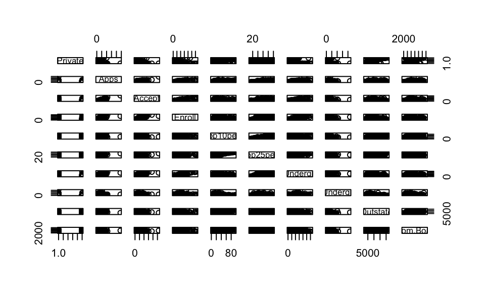

```r
pairs(college[,1:10])
```

### iii.Side-by-side boxplots

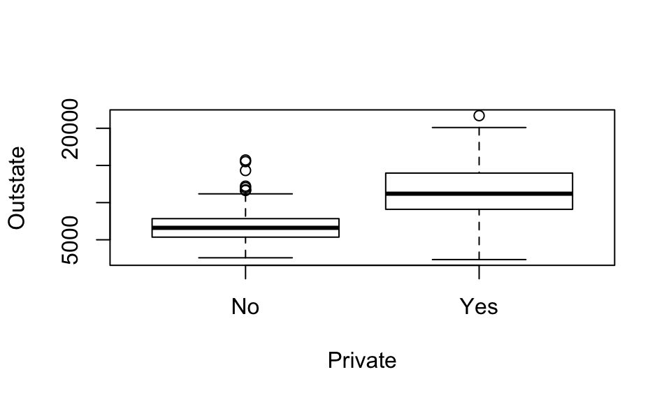

```r
plot(Outstate ~ Private, data = college)
```

### iv. Create “Elite”" variable

```r
Elite = rep("No", nrow(college))
Elite[college$Top10perc>50] = "Yes"
Elite= as.factor(Elite)
college = data.frame(college,Elite)
summary(college)
```

```
##  Private        Apps           Accept          Enroll       Top10perc
##  No :212   Min.   :   81   Min.   :   72   Min.   :  35   Min.   : 1.00
##  Yes:565   1st Qu.:  776   1st Qu.:  604   1st Qu.: 242   1st Qu.:15.00
##            Median : 1558   Median : 1110   Median : 434   Median :23.00
##            Mean   : 3002   Mean   : 2019   Mean   : 780   Mean   :27.56
##            3rd Qu.: 3624   3rd Qu.: 2424   3rd Qu.: 902   3rd Qu.:35.00
##            Max.   :48094   Max.   :26330   Max.   :6392   Max.   :96.00
##    Top25perc      F.Undergrad     P.Undergrad         Outstate
##  Min.   :  9.0   Min.   :  139   Min.   :    1.0   Min.   : 2340
##  1st Qu.: 41.0   1st Qu.:  992   1st Qu.:   95.0   1st Qu.: 7320
##  Median : 54.0   Median : 1707   Median :  353.0   Median : 9990
##  Mean   : 55.8   Mean   : 3700   Mean   :  855.3   Mean   :10441
##  3rd Qu.: 69.0   3rd Qu.: 4005   3rd Qu.:  967.0   3rd Qu.:12925
##  Max.   :100.0   Max.   :31643   Max.   :21836.0   Max.   :21700
##    Room.Board       Books           Personal         PhD
##  Min.   :1780   Min.   :  96.0   Min.   : 250   Min.   :  8.00
##  1st Qu.:3597   1st Qu.: 470.0   1st Qu.: 850   1st Qu.: 62.00
##  Median :4200   Median : 500.0   Median :1200   Median : 75.00
##  Mean   :4358   Mean   : 549.4   Mean   :1341   Mean   : 72.66
##  3rd Qu.:5050   3rd Qu.: 600.0   3rd Qu.:1700   3rd Qu.: 85.00
##  Max.   :8124   Max.   :2340.0   Max.   :6800   Max.   :103.00
##     Terminal       S.F.Ratio      perc.alumni        Expend
##  Min.   : 24.0   Min.   : 2.50   Min.   : 0.00   Min.   : 3186
##  1st Qu.: 71.0   1st Qu.:11.50   1st Qu.:13.00   1st Qu.: 6751
##  Median : 82.0   Median :13.60   Median :21.00   Median : 8377
##  Mean   : 79.7   Mean   :14.09   Mean   :22.74   Mean   : 9660
##  3rd Qu.: 92.0   3rd Qu.:16.50   3rd Qu.:31.00   3rd Qu.:10830
##  Max.   :100.0   Max.   :39.80   Max.   :64.00   Max.   :56233
##    Grad.Rate      Elite
##  Min.   : 10.00   No :699
##  1st Qu.: 53.00   Yes: 78
##  Median : 65.00
##  Mean   : 65.46
##  3rd Qu.: 78.00
##  Max.   :118.00
```

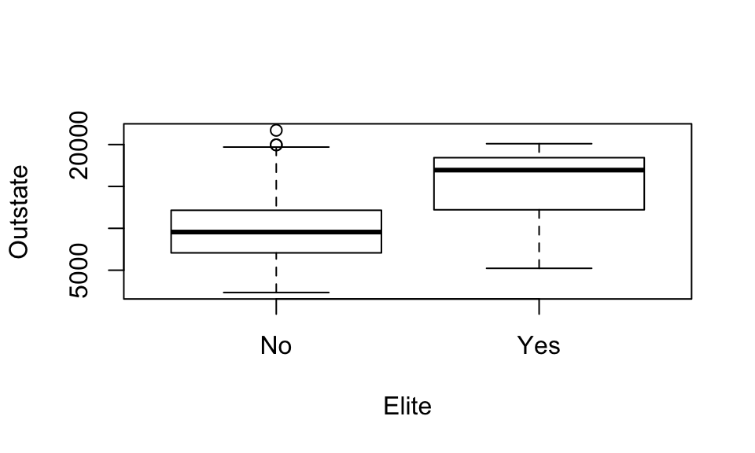

```r
plot(Outstate ~ Elite, data = college)
```

### v. Histograms

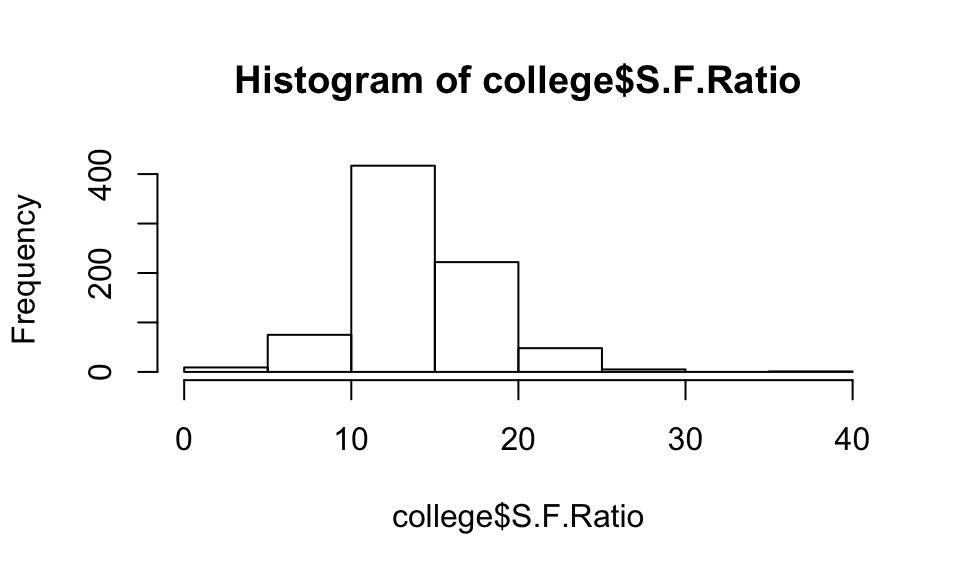

```r
#par(mfrow=c(2,2))
hist(college$S.F.Ratio)
```

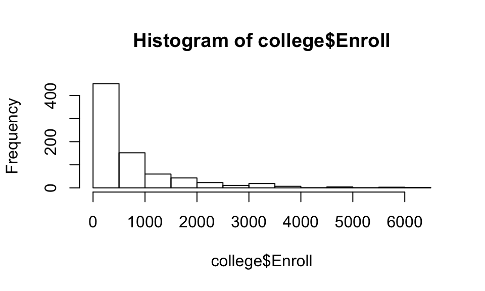

```r
hist(college$Enroll)
```

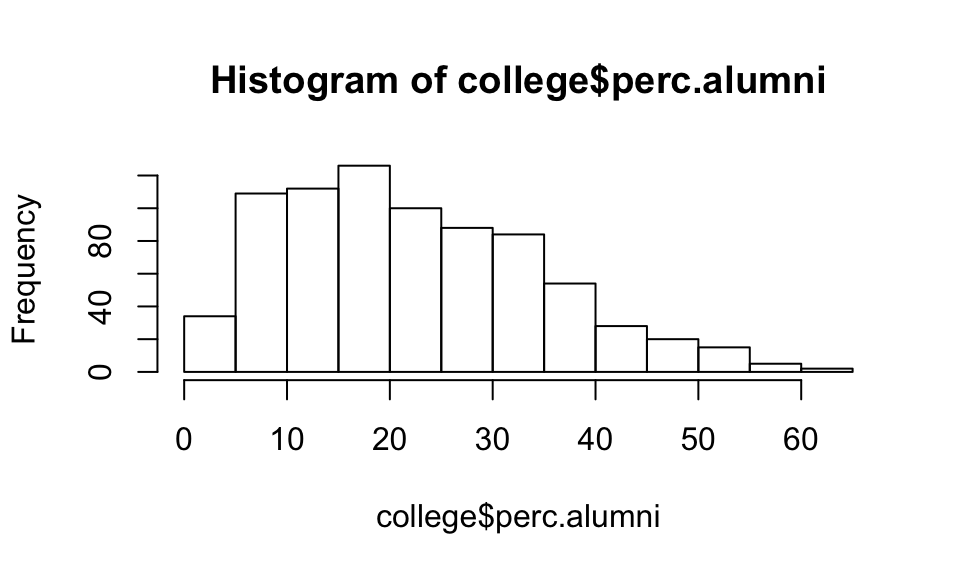

```r
hist(college$perc.alumni)
```

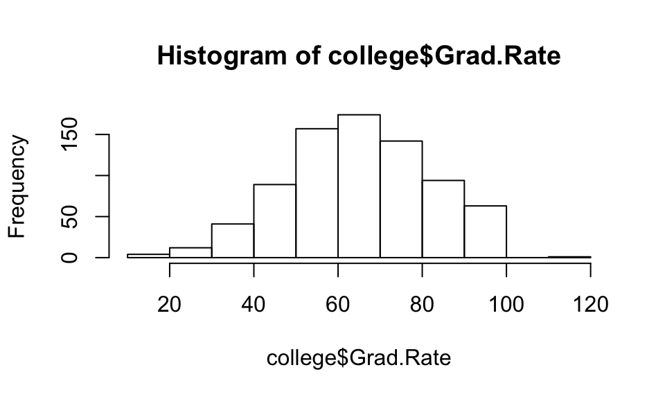

```r
hist(college$Grad.Rate)
```

# Exercise 9 in ISL Section 2.4

```r
auto_file_name <- "/Users/JingjingYang/Dropbox/fall 2015/253 statistical computing/Auto.csv"
Auto <- read.csv(auto_file_name, header = T, na.strings = "?")
```

## (a) Quantitative or quanlitative predictors

Qualitative predictors include: name, origin, year. All other predictors are quantitative.

## (b) Range of each quantitative predictor

```r
sapply(Auto[,-c(7,8,9)],range, na.rm= TRUE)
```

```
##       mpg cylinders displacement horsepower weight acceleration
## [1,]  9.0         3           68         46   1613          8.0
## [2,] 46.6         8          455        230   5140         24.8
```

## (c) Mean and sd of each quantitative predictor

```r
sapply(Auto[,-c(7,8,9)],mean, na.rm= TRUE)
```

```
##          mpg    cylinders displacement   horsepower       weight
##    23.515869     5.458438   193.532746   104.469388  2970.261965
## acceleration
##    15.555668
```

```r
sapply(Auto[,-c(7,8,9)],sd, na.rm= TRUE)
```

```
##          mpg    cylinders displacement   horsepower       weight
##     7.825804     1.701577   104.379583    38.491160   847.904119
## acceleration
##     2.749995
```

## (d) Remove 10th through 85th observations

```r
sapply(Auto[-c(10:85),-c(7,8,9)],range, na.rm=TRUE)
```

```
##       mpg cylinders displacement horsepower weight acceleration
## [1,] 11.0         3           68         46   1649          8.5
## [2,] 46.6         8          455        230   4997         24.8
```

```r
sapply(Auto[-c(10:85),-c(7,8,9)],mean, na.rm=TRUE)
```

```
##          mpg    cylinders displacement   horsepower       weight
##    24.438629     5.370717   187.049844   100.955836  2933.962617
## acceleration
##    15.723053
```

```r
sapply(Auto[-c(10:85),-c(7,8,9)],sd, na.rm=TRUE)
```

```
##          mpg    cylinders displacement   horsepower       weight
##     7.908184     1.653486    99.635385    35.895567   810.642938
## acceleration
##     2.680514
```

## (e) Investigate the predictors graphically

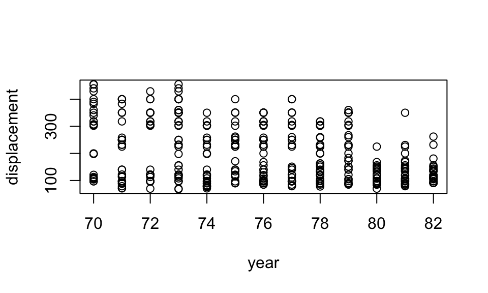

```r
plot(displacement~year, data = Auto)
```

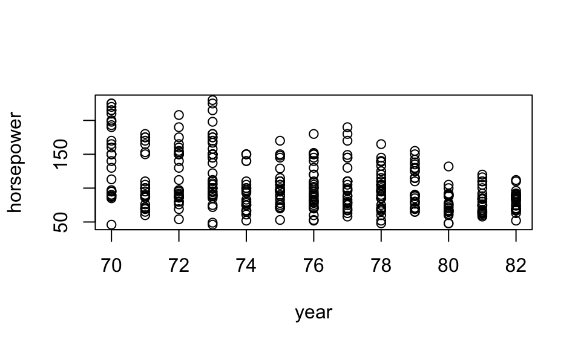

```r
plot(horsepower~year, data = Auto)
```

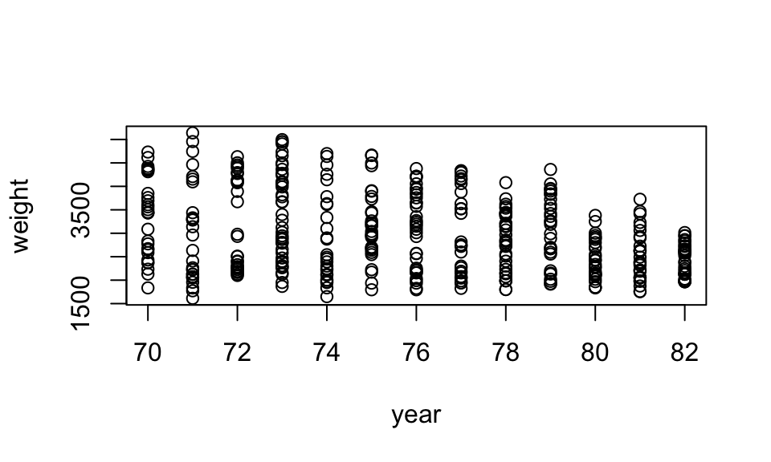

```r
plot(weight~year, data = Auto)
```

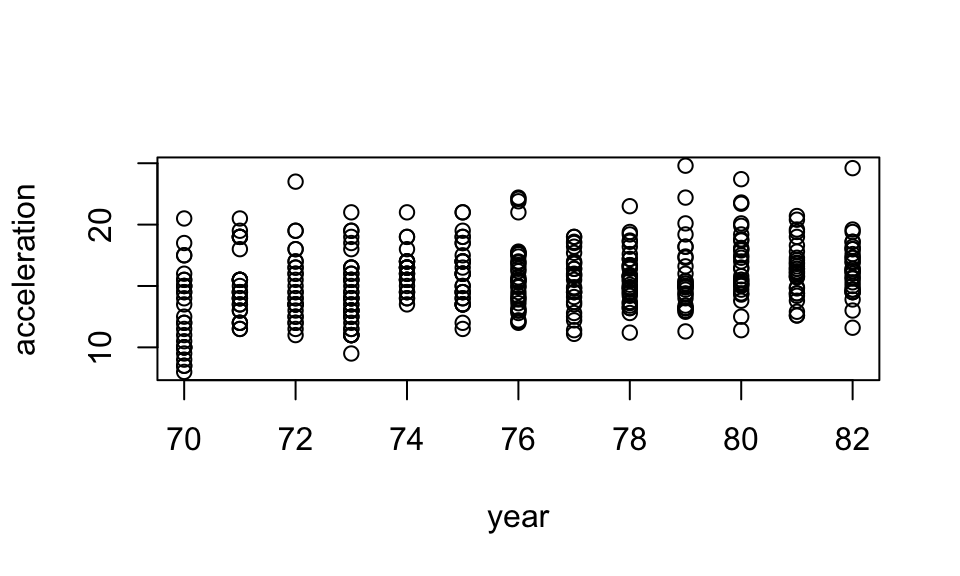

```r
plot(acceleration~year, data = Auto)
```

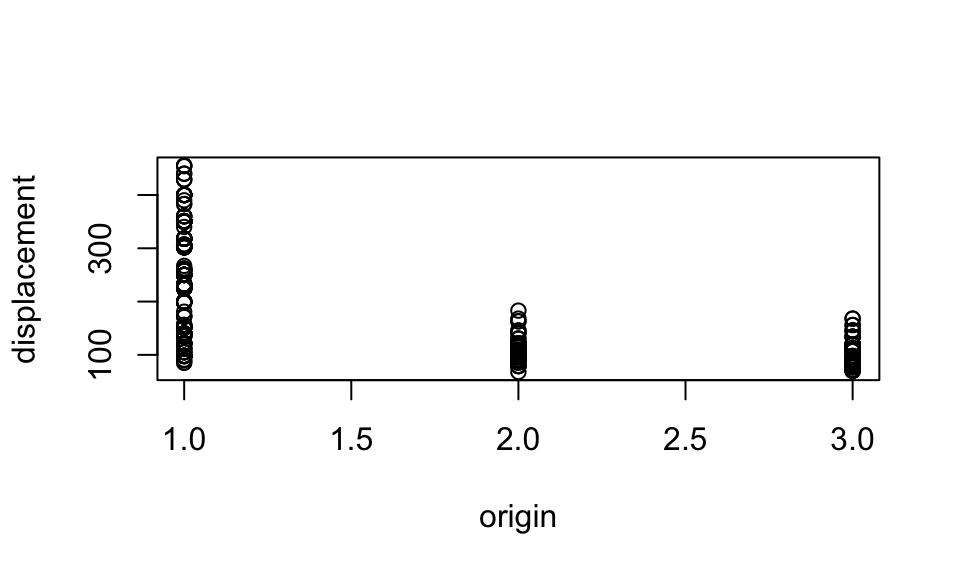

```r
plot(displacement~origin, data = Auto)
```

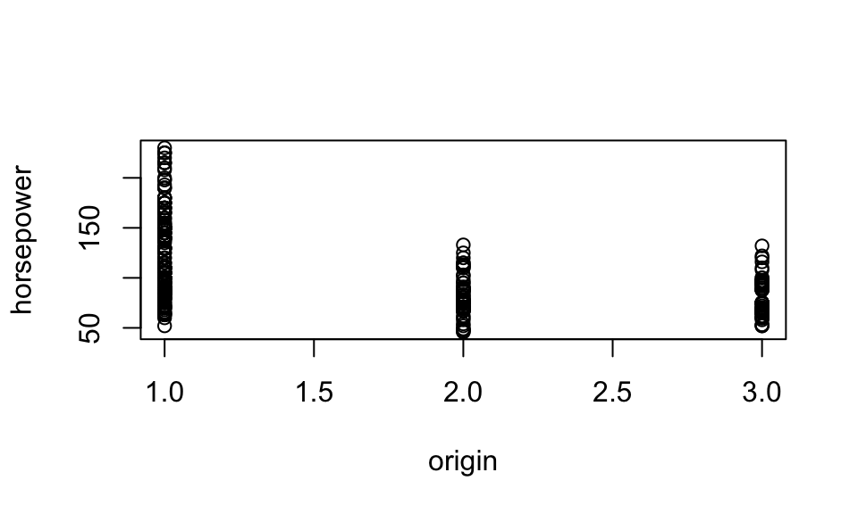

```r
plot(horsepower~origin, data = Auto)
```

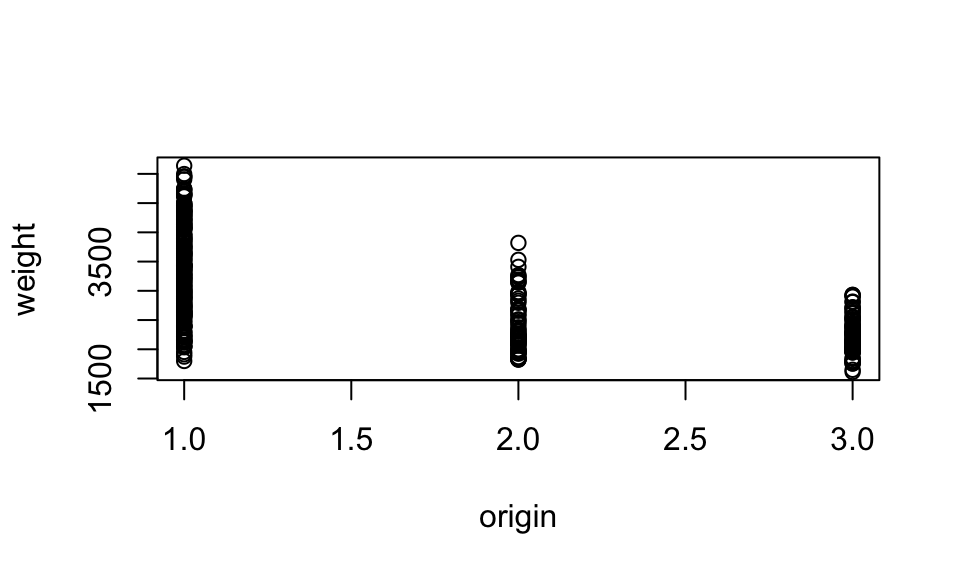

```r
plot(weight~origin, data = Auto)
```

## (f) Predicting gas mileage

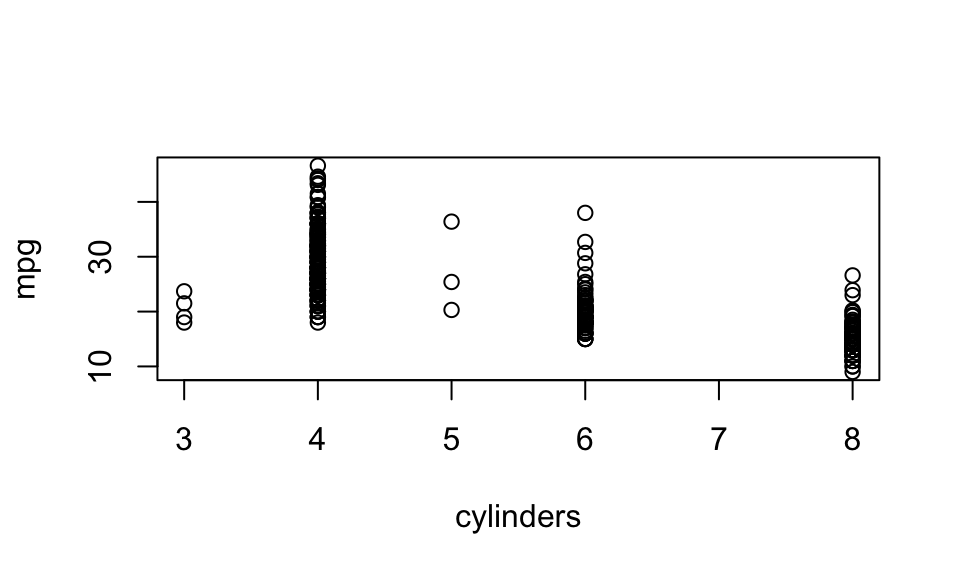

```r
plot(mpg~cylinders, data = Auto)
```

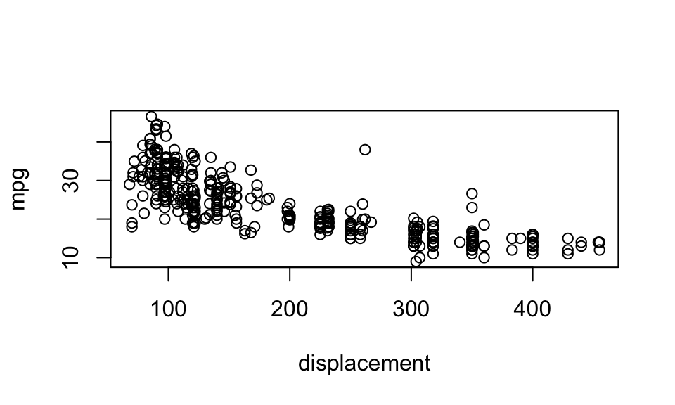

```r
plot(mpg~displacement, data = Auto)
```

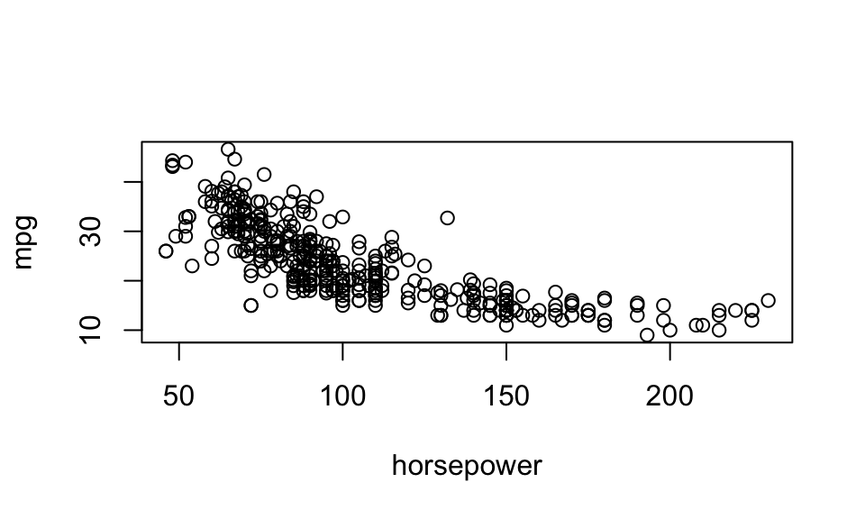

```r
plot(mpg~horsepower, data = Auto)
```

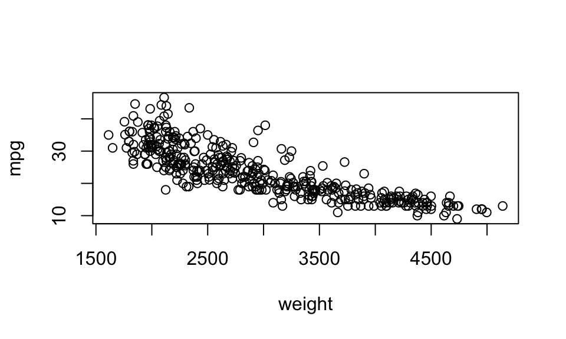

```r
plot(mpg~weight, data = Auto)
```

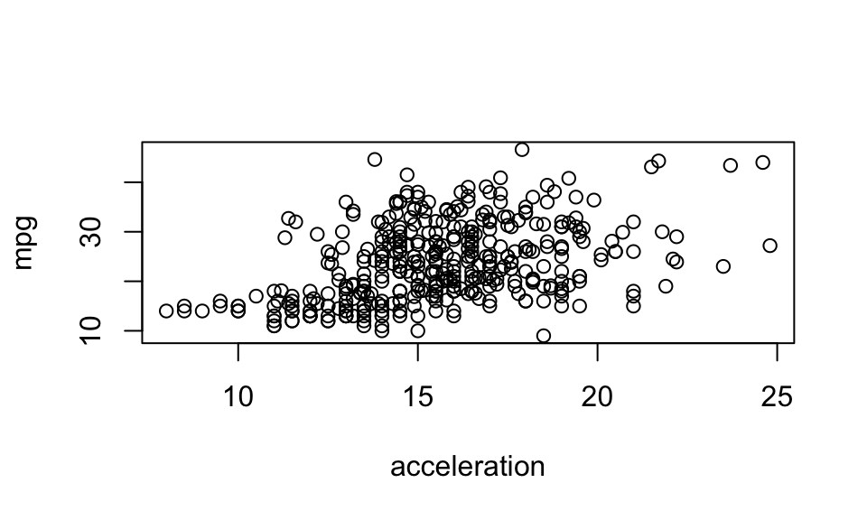

```r
plot(mpg~acceleration, data = Auto)
```

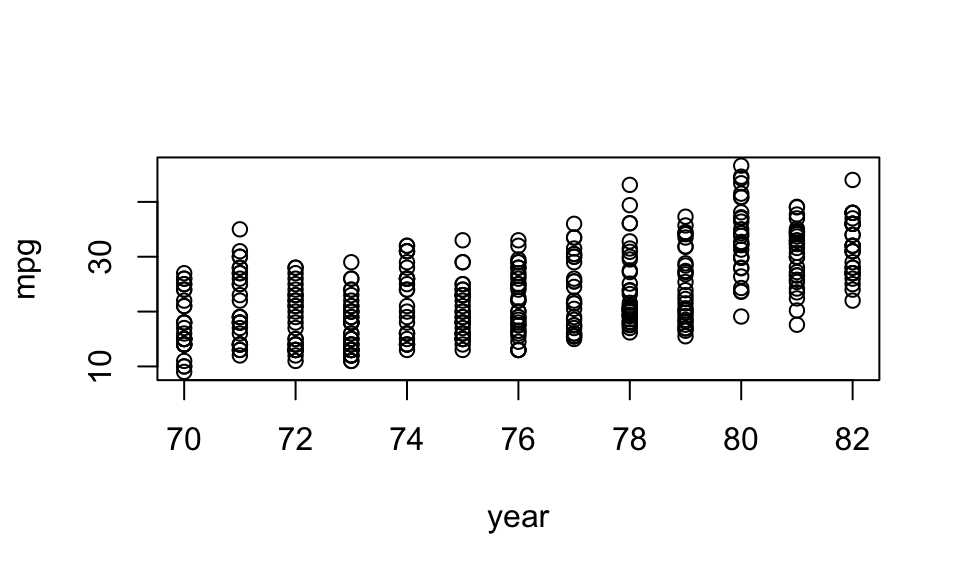

```r
plot(mpg~year, data = Auto)
```

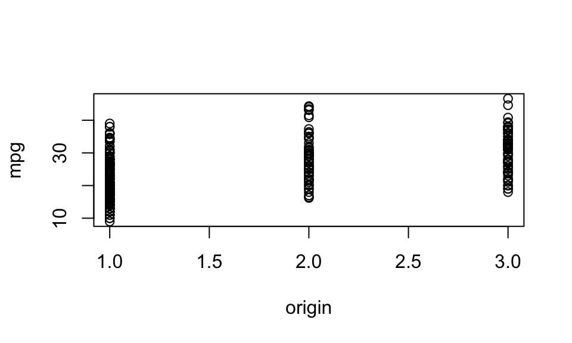

```r
plot(mpg~origin, data = Auto)
```

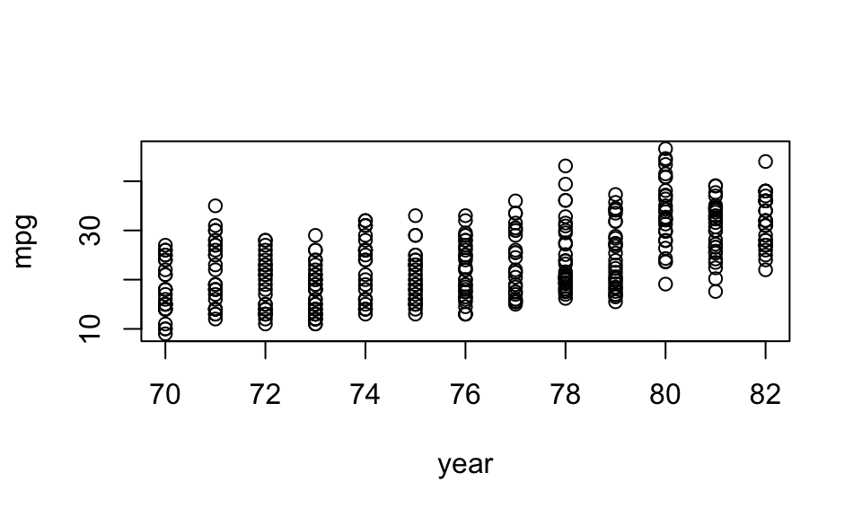

```r
plot(mpg~year, data = Auto)
```

According to the scatterplots above, I conclude that displacement, horsepower, weight are the predictors most likely to be helpful in predicting mpg because they demonstrate the strongest relationship with mpg.

# Exercise 2 in ISL Section 2.4

## (a) Factors that affect CEO salary.

This is a regression problem and we are most interested in inference. Sample size n is 500, and the number of predictors p is 4.

## (b) Lauching a new product

This is a classification problem and we are most interested in prediction. The sample size n is 20, and the number of predictors p is 14.

## (c) Predict change in US dollar

This is a regression problem and we are most interested in prediction. The sample size is 52, and the number of predictors p is 4.

# Exercise 7 in ISL Section 2.4

## (a) Euclidean distance

Distance between observation 1 and the test point: 3 Distance between observation 2 and the test point: 2 Distance between observation 3 and the test point: sqrt(10) Distance between observation 4 and the test point: sqrt(5) Distance between observation 5 and the test point: sqrt(2) Distance between observation 6 and the test point: sqrt(5)

## (b) Given K = 1

Our prediction will be Green, because the closest observation to the test point observation 5, is Green.

## (c) Given K = 3

The three closest observations to the test point are observation 2, observation 5, and observation 4 ( or 6, since they are equally far from the test point). Their values are Red, Green, and Green (Red) respectively. So in this case, the test point can be either Green or Red.

## (d) Best value for K given highly non-linear decision boundry

If the Bayes decision boundry is highly non-linear, we expect the best value for K to be small, because small K values lead to flexible boundries and large K values have more lindear boundries.